# Project 5 - Analysis and Report

Data Management Using SAS

Author

Sean Vieau

Published

December 16, 2024

# Introduction

For this project, we implement the Data Analysis Plan (DAP) we created for project 4, and analyze the PI’s research question and our own question of interest. Importantly, we write SAS code to create a reproducible pdf report directly from SAS.

# Data Analysis Plan

[figure not shown]

### Research Questions

# Set Up

**Connect to SAS**

#### Connect to SAS

```r
# This code connects to SAS On Demand
library(configSAS)
configSAS::set_sas_engine()
```

```
Using SAS Config named: oda
SAS Connection established. Subprocess id is 32628
```

````r
#  This code allows you to run ```{sas}``` chunks
sas = knitr::opts_chunk$get("sas")
````

**Macros**

#### Macros

```sas
* Set Courseroot;
%LET CourseRoot = /home/u63376223/sasuser.v94/Data Management Using SAS;
```

**Libraries**

#### Libraries

```sas
* Create libraries;
LIBNAME Source "&CourseRoot/BRFSS/Data/1_Source";
LIBNAME Impt "&CourseRoot/BRFSS/Data/2_Import";
```

**System Options**

#### System Options

```sas
* Suppress error messages that occur when SAS cannot find a format or an informat
OPTIONS NOFMTERR;
```

**Formats**

#### Formats

```sas
*How do we want the variable names to display?;
PROC FORMAT;
    VALUE $Varnames
    "BMI" = "BMI"
    "SmokeTime" = "Years Smoked"
    "Age" = "Age";
    RUN;
```

# Descriptive Statistics

## Table 1A: Continuous Variables

**Create Data Set**

#### Create Data Set of Means and Standard Deviations

```sas
TITLE "Table 1A. Means and Standard Deviation";
*Step 1- Use ODS TRACE to identify name of Table;
*Step 2- Use ODS OUTPUT to create a dataset;
/*  ods trace on;*/
ODS OUTPUT Table = Table1_pre;
PROC TABULATE DATA = IMPT.BRFSS_FINAL MISSING;
    VAR BMI SmokeTime Age;
    TABLE BMI SmokeTime Age, mean*f=comma9.2 std*f=comma9.2/nocellmerge;
    RUN;
/*  ods trace off;*/
```

#### Examine Table

```sas
* Step 3- Examine table;
PROC PRINT DATA = Table1_pre;
    RUN;
```

**lst**

<!DOCTYPE html>

Table 1A. Means and Standard Deviation

| Obs | *TYPE* | *PAGE* | *TABLE* | BMI_Mean | BMI_Std | SmokeTime_Mean | SmokeTime_Std | Age_Mean | Age_Std |
| --- | --- | --- | --- | --- | --- | --- | --- | --- | --- |
| 1 | 0 | 1 | 1 | 29.1836 | 6.66191 | 6.03782 | 11.8816 | 1.98128 | 0.81638 |

**log**

```
17                                                         The SAS System                      Friday, December 19, 2025 03:08:00 AM

190        ods listing close;ods html5 (id=saspy_internal) file=_tomods1 options(bitmap_mode='inline') device=svg style=HTMLBlue;
190      ! ods graphics on / outputfmt=png;
191
192        * Step 3- Examine table;
193        PROC PRINT DATA = Table1_pre;
194         RUN;
195
196
197        ods html5 (id=saspy_internal) close;ods listing;
198
18                                                         The SAS System                      Friday, December 19, 2025 03:08:00 AM

199
```

Top of Tabset

**Clean Data Set**

#### Format Data Set to be More Visually Appealling

```sas
* Step 4-  Clean the dataset with the output to look pretty;
DATA Table1_pre2;
    SET Table1_pre;
        BMI = strip(put(BMI_mean,8.2))||" ("||strip(put(BMI_std, 8.2))||")";
        SmokeTime = strip(put(SmokeTime_mean,8.2))||" ("||strip(put(SmokeTime_std, 8.2))||")";
        Age = strip(put(Age_mean,8.2))||" ("||strip(put(Age_std, 8.2))||")";
        RUN;
```

#### Examine Table

```sas
* Step 5- Examine table;
PROC PRINT DATA = table1_pre2;
    VAR BMI SmokeTime Age;
    RUN;
```

**lst**

<!DOCTYPE html>

Table 1A. Means and Standard Deviation

| Obs | BMI | SmokeTime | Age |
| --- | --- | --- | --- |
| 1 | 29.18 (6.66) | 6.04 (11.88) | 1.98 (0.82) |

**log**

```
21                                                         The SAS System                      Friday, December 19, 2025 03:08:00 AM

218        ods listing close;ods html5 (id=saspy_internal) file=_tomods1 options(bitmap_mode='inline') device=svg style=HTMLBlue;
218      ! ods graphics on / outputfmt=png;
219
220        * Step 5- Examine table;
221        PROC PRINT DATA = table1_pre2;
222         VAR BMI SmokeTime Age;
223         RUN;
224
225
226        ods html5 (id=saspy_internal) close;ods listing;
227
22                                                         The SAS System                      Friday, December 19, 2025 03:08:00 AM

228
```

Top of Tabset

**Transpose Data Set**

```sas
*Step 5. Tranpose the data;
PROC TRANSPOSE DATA = Table1_Pre2 OUT = Table1_Clean(RENAME = (_NAME_ = Variable Col1 = MeanSD));
    VAR BMI SmokeTime Age;
    RUN;
```

#### Examine Table

```sas
PROC PRINT DATA = Table1_Clean LABEL NOOBS;
    RUN;
```

**lst**

<!DOCTYPE html>

Table 1A. Means and Standard Deviation

| NAME OF FORMER VARIABLE | MeanSD |
| --- | --- |
| BMI | 29.18 (6.66) |
| SmokeTime | 6.04 (11.88) |
| Age | 1.98 (0.82) |

**log**

```
25                                                         The SAS System                      Friday, December 19, 2025 03:08:00 AM

244        ods listing close;ods html5 (id=saspy_internal) file=_tomods1 options(bitmap_mode='inline') device=svg style=HTMLBlue;
244      ! ods graphics on / outputfmt=png;
245
246        PROC PRINT DATA = Table1_Clean LABEL NOOBS;
247         RUN;
248
249
250        ods html5 (id=saspy_internal) close;ods listing;
251
26                                                         The SAS System                      Friday, December 19, 2025 03:08:00 AM

252
```

Top of Tabset

**Final Table**

#### Reapply Labels

```sas
* Reapply Labels;
DATA Table1_Clean;
    SET Table1_Clean;
    LABEL Variable = "Variable" MeanSd = "Mean(SD)";
    FORMAT Variable $Varnames.;
    RUN;
```

#### Examine Final Table

```sas
* Examine Final clean table 1a;
PROC PRINT DATA = Table1_Clean LABEL NOOBS;
    RUN;
TITLE;
```

**lst**

<!DOCTYPE html>

Table 1A. Means and Standard Deviation

| Variable | Mean(SD) |
| --- | --- |
| BMI | 29.18 (6.66) |
| Years Smoked | 6.04 (11.88) |
| Age | 1.98 (0.82) |

**log**

```
29                                                         The SAS System                      Friday, December 19, 2025 03:08:00 AM

270        ods listing close;ods html5 (id=saspy_internal) file=_tomods1 options(bitmap_mode='inline') device=svg style=HTMLBlue;
270      ! ods graphics on / outputfmt=png;
271
272        * Examine Final clean table 1a;
273        PROC PRINT DATA = Table1_Clean LABEL NOOBS;
274         RUN;
275        TITLE;
276
277
278        ods html5 (id=saspy_internal) close;ods listing;
279
30                                                         The SAS System                      Friday, December 19, 2025 03:08:00 AM

280
```

Top of Tabset

## Table 1B: Categorical Variables

**Create Data Set**

#### Create Data Set of Frequencies and Proportions

```sas
*Step 1- Use ODS TRACE to identify name of Table;
*Step 2- Use OUT to create a dataset;
*ODS TRACE ON;
TITLE "Table 1B. Frequency and Proportion";
PROC FREQ DATA = IMPT.BRFSS_FINAL;
    TABLES Marijuana / OUT = Marijuana_Freq;
    TABLES Cancer / OUT = Cancer_Freq;
    TABLES Alcohol / OUT = Alcohol_Freq;
    RUN;
*ODS TRACE OFF;
```

**lst**

<!DOCTYPE html>

Table 1B. Frequency and Proportion

The FREQ Procedure

| Marijuana use in past 30 days Marijuana | Marijuana use in past 30 days Frequency | Marijuana use in past 30 days Percent | Marijuana use in past 30 days Cumulative Frequency | Marijuana use in past 30 days Cumulative Percent |
| --- | --- | --- | --- | --- |
| Yes | 3220 | 14.35 | 3220 | 14.35 |
| No | 19214 | 85.65 | 22434 | 100.00 |

Frequency Missing = 25898

| Ever had Cancer Cancer | Ever had Cancer Frequency | Ever had Cancer Percent | Ever had Cancer Cumulative Frequency | Ever had Cancer Cumulative Percent |
| --- | --- | --- | --- | --- |
| Yes | 4234 | 8.77 | 4234 | 8.77 |
| No | 44046 | 91.23 | 48280 | 100.00 |

Frequency Missing = 52

| Consumed alcohol in past 30 days Alcohol | Consumed alcohol in past 30 days Frequency | Consumed alcohol in past 30 days Percent | Consumed alcohol in past 30 days Cumulative Frequency | Consumed alcohol in past 30 days Cumulative Percent |
| --- | --- | --- | --- | --- |
| Yes | 25303 | 60.53 | 25303 | 60.53 |
| No | 16501 | 39.47 | 41804 | 100.00 |

Frequency Missing = 6528

**log**

```
31                                                         The SAS System                      Friday, December 19, 2025 03:08:00 AM

283        ods listing close;ods html5 (id=saspy_internal) file=_tomods1 options(bitmap_mode='inline') device=svg style=HTMLBlue;
283      ! ods graphics on / outputfmt=png;
284
285        *Step 1- Use ODS TRACE to identify name of Table;
286        *Step 2- Use OUT to create a dataset;
287        *ODS TRACE ON;
288        TITLE "Table 1B. Frequency and Proportion";
289        PROC FREQ DATA = IMPT.BRFSS_FINAL;
290         TABLES Marijuana / OUT = Marijuana_Freq;
291         TABLES Cancer / OUT = Cancer_Freq;
292         TABLES Alcohol / OUT = Alcohol_Freq;
293         RUN;
294        *ODS TRACE OFF;
295
296
297        ods html5 (id=saspy_internal) close;ods listing;
298
32                                                         The SAS System                      Friday, December 19, 2025 03:08:00 AM

299
```

Top of Tabset

**Clean Data Set**

### Handle Missing Values and Examine Data Sets

#### Marijuana Usage

```sas
* Step 3- Examine data set;
* Handle Missing;
DATA Marijuana_Freq;
    SET Marijuana_Freq;
    IF Marijuana = . THEN DELETE;
    ELSE IF Marijuana = 1 THEN Marijuana_Status = "Marijuana Usage: Yes";
    ELSE IF Marijuana = 2 THEN Marijuana_Status = "Marijuana Usage: No";
    DROP Marijuana;
    RENAME Marijuana_Status = Marijuana;
    RUN;

PROC PRINT DATA = Marijuana_Freq;
    RUN;
```

**lst**

<!DOCTYPE html>

Table 1B. Frequency and Proportion

| Obs | COUNT | PERCENT | Marijuana |
| --- | --- | --- | --- |
| 1 | 3220 | 14.3532 | Marijuana Usage: Yes |
| 2 | 19214 | 85.6468 | Marijuana Usage: No |

**log**

```
33                                                         The SAS System                      Friday, December 19, 2025 03:08:00 AM

302        ods listing close;ods html5 (id=saspy_internal) file=_tomods1 options(bitmap_mode='inline') device=svg style=HTMLBlue;
302      ! ods graphics on / outputfmt=png;
303
304        * Step 3- Examine data set;
305        * Handle Missing;
306        DATA Marijuana_Freq;
307         SET Marijuana_Freq;
308         IF Marijuana = . THEN DELETE;
309         ELSE IF Marijuana = 1 THEN Marijuana_Status = "Marijuana Usage: Yes";
310         ELSE IF Marijuana = 2 THEN Marijuana_Status = "Marijuana Usage: No";
311         DROP Marijuana;
312         RENAME Marijuana_Status = Marijuana;
313         RUN;
314
315        PROC PRINT DATA = Marijuana_Freq;
316         RUN;
317
318
319        ods html5 (id=saspy_internal) close;ods listing;
320
34                                                         The SAS System                      Friday, December 19, 2025 03:08:00 AM

321
```

#### Cancer

```sas
* Handle Missing;
DATA Cancer_Freq;
    SET Cancer_Freq;
    IF Cancer = . THEN DELETE;
    ELSE IF Cancer = 1 THEN Cancer_Status = "Had Cancer: Yes";
    ELSE IF Cancer = 2 THEN Cancer_Status = "Had Cancer: No";
    DROP Cancer;
    RENAME Cancer_Status = Cancer;
    RUN;

PROC PRINT DATA = Cancer_Freq;
    RUN;
```

**lst**

<!DOCTYPE html>

Table 1B. Frequency and Proportion

| Obs | COUNT | PERCENT | Cancer |
| --- | --- | --- | --- |
| 1 | 4234 | 8.7697 | Had Cancer: Yes |
| 2 | 44046 | 91.2303 | Had Cancer: No |

**log**

```
35                                                         The SAS System                      Friday, December 19, 2025 03:08:00 AM

324        ods listing close;ods html5 (id=saspy_internal) file=_tomods1 options(bitmap_mode='inline') device=svg style=HTMLBlue;
324      ! ods graphics on / outputfmt=png;
325
326        * Handle Missing;
327        DATA Cancer_Freq;
328         SET Cancer_Freq;
329         IF Cancer = . THEN DELETE;
330         ELSE IF Cancer = 1 THEN Cancer_Status = "Had Cancer: Yes";
331         ELSE IF Cancer = 2 THEN Cancer_Status = "Had Cancer: No";
332         DROP Cancer;
333         RENAME Cancer_Status = Cancer;
334         RUN;
335
336        PROC PRINT DATA = Cancer_Freq;
337         RUN;
338
339
340        ods html5 (id=saspy_internal) close;ods listing;
341
36                                                         The SAS System                      Friday, December 19, 2025 03:08:00 AM

342
```

#### Alcohol Usage

```sas
* Handle Missing;
DATA Alcohol_Freq;
    SET Alcohol_Freq;
    IF Alcohol = . THEN DELETE;
    ELSE IF Alcohol = 1 THEN Alcohol_Status = "Drink Alcohol: Yes";
    ELSE IF Alcohol = 2 THEN Alcohol_Status = "Drink Alcohol: No";
    DROP Alcohol;
    RENAME Alcohol_Status = Alcohol;
    RUN;

PROC PRINT DATA = Alcohol_Freq;
    RUN;
```

**lst**

<!DOCTYPE html>

Table 1B. Frequency and Proportion

| Obs | COUNT | PERCENT | Alcohol |
| --- | --- | --- | --- |
| 1 | 25303 | 60.5277 | Drink Alcohol: Yes |
| 2 | 16501 | 39.4723 | Drink Alcohol: No |

**log**

```
37                                                         The SAS System                      Friday, December 19, 2025 03:08:00 AM

345        ods listing close;ods html5 (id=saspy_internal) file=_tomods1 options(bitmap_mode='inline') device=svg style=HTMLBlue;
345      ! ods graphics on / outputfmt=png;
346
347        * Handle Missing;
348        DATA Alcohol_Freq;
349         SET Alcohol_Freq;
350         IF Alcohol = . THEN DELETE;
351         ELSE IF Alcohol = 1 THEN Alcohol_Status = "Drink Alcohol: Yes";
352         ELSE IF Alcohol = 2 THEN Alcohol_Status = "Drink Alcohol: No";
353         DROP Alcohol;
354         RENAME Alcohol_Status = Alcohol;
355         RUN;
356
357        PROC PRINT DATA = Alcohol_Freq;
358         RUN;
359
360
361        ods html5 (id=saspy_internal) close;ods listing;
362
38                                                         The SAS System                      Friday, December 19, 2025 03:08:00 AM

363
```

**Final Table**

#### Concatenate and Examine Final Data Set

```sas
*Step 4- Concatanate the data;
DATA Table1b_Combine;
    SET Marijuana_Freq(Rename = (Marijuana = Variable))
        Cancer_Freq(Rename = (Cancer = Variable))
        Alcohol_Freq(Rename = (Alcohol = Variable));
    N_PERCENT = strip(put(count,8.)||" ("||strip(put(round(percent,0.2),8.))||"%)");
    LABEL N_PERCENT = "N(%)" Variable = "Variable";
    DROP COUNT PERCENT;
    RUN;

PROC PRINT DATA = Table1b_Combine LABEL NOOBS;
    RUN;
TITLE;
```

**lst**

<!DOCTYPE html>

Table 1B. Frequency and Proportion

| Variable | N(%) |
| --- | --- |
| Marijuana Usage: Yes | 3220 (14%) |
| Marijuana Usage: No | 19214 (86%) |
| Had Cancer: Yes | 4234 (9%) |
| Had Cancer: No | 44046 (91%) |
| Drink Alcohol: Yes | 25303 (61%) |
| Drink Alcohol: No | 16501 (39%) |

**log**

```
39                                                         The SAS System                      Friday, December 19, 2025 03:08:00 AM

366        ods listing close;ods html5 (id=saspy_internal) file=_tomods1 options(bitmap_mode='inline') device=svg style=HTMLBlue;
366      ! ods graphics on / outputfmt=png;
367
368        *Step 4- Concatanate the data;
369        DATA Table1b_Combine;
370         SET Marijuana_Freq(Rename = (Marijuana = Variable))
371             Cancer_Freq(Rename = (Cancer = Variable))
372             Alcohol_Freq(Rename = (Alcohol = Variable));
373         N_PERCENT = strip(put(count,8.)||" ("||strip(put(round(percent,0.2),8.))||"%)");
374         LABEL N_PERCENT = "N(%)" Variable = "Variable";
375         DROP COUNT PERCENT;
376         RUN;
377
378        PROC PRINT DATA = Table1b_Combine LABEL NOOBS;
379         RUN;
380        TITLE;
381
382
383        ods html5 (id=saspy_internal) close;ods listing;
384
40                                                         The SAS System                      Friday, December 19, 2025 03:08:00 AM

385
```

# Analyses

## Table 2: T-Test

**Means and Standard Deviations**

#### Acquire Means and Standard Deviations for each State

```sas
*Step 1- Use ODS TRACE to identify name of Table;
*Step 2- Use ODS OUTPUT to create a dataset;
/*  ods trace on;*/
TITLE "Table 2. T-Test of BMI By State";
ODS OUTPUT TABLE = Table2_pre;
    PROC TABULATE DATA = IMPT.BRFSS_FINAL;
    WHERE State NE "9";
    CLASS State;
    VAR BMI;
    TABLE BMI,(State)*(mean*f=comma9.2 std*f=comma9.2)/nocellmerge;
    RUN;
/*  ods trace off;*/
```

[output not shown]

**lst**

**log**

[output not shown]

#### Examine Table

```sas
* Step 3- Examine table;
PROC PRINT DATA = Table2_Pre;
    RUN;
```

**lst**

**log**

[output not shown]

#### Manipulate Table for Desired Appearance

```sas
* Step 4- Manipulate SAS Table for desired appearance;
DATA table2_pre;
    SET table2_pre;

    /* Assuming BMI_Mean and BMI_Std are the correct variable names for means and standard deviations */
    ARRAY clean(1) $12 BMI_clean; /* Create a new character variable for the formatted result */
    ARRAY means(1) BMI_Mean;
    ARRAY sds(1) BMI_Std;

    DO i = 1 TO dim(clean);
        clean(i) = STRIP(PUT(means(i), 9.2)) || " (" || STRIP(PUT(sds(i), 9.2)) || ")";
    END;

    KEEP State BMI_clean; /* Keep the state and new formatted BMI variable */
    RENAME BMI_clean = BMI; /* Rename the formatted variable to BMI */
RUN;

* Step 5- Check table;
PROC PRINT DATA = Table2_pre;
    RUN;
```

**lst**

**log**

[output not shown]

#### Transpose Table

```sas
* Step 6- Transpose;
PROC TRANSPOSE DATA = Table2_pre OUT = Table2_Clean;
    VAR BMI;
    ID State;
    RUN;
```

#### Examine Transposed Table

```sas
* Step 7- Check table;
PROC PRINT DATA = Table2_Clean;
    RUN;
```

**lst**

**log**

```
49                                                         The SAS System                      Friday, December 19, 2025 03:08:00 AM

464        ods listing close;ods html5 (id=saspy_internal) file=_tomods1 options(bitmap_mode='inline') device=svg style=HTMLBlue;
464      ! ods graphics on / outputfmt=png;
465
466        * Step 7- Check table;
467        PROC PRINT DATA = Table2_Clean;
468         RUN;
469
470
471        ods html5 (id=saspy_internal) close;ods listing;
472
50                                                         The SAS System                      Friday, December 19, 2025 03:08:00 AM

473
```

Top of Tabset

**Perform T-Test**

#### Perform the T-Test and Save Results Table

```sas
*Step 8- Use ODS TRACE to identify name of Table;
*Step 9- Use ODS OUTPUT to create a dataset;
/*  ods trace on;*/
ODS OUTPUT ttests=ttest_results;
    PROC TTEST DATA = IMPT.BRFSS_FINAL;
    WHERE State NE "9";
    CLASS State;
    VAR BMI;
    RUN;
/*  ods trace off;*/
```

[output not shown]

**lst**

**log**

[output not shown]

#### Examine T-Test Results Table

```sas
*Step 10 Look at the SAS table;
PROC PRINT DATA = ttest_results;
    RUN;
```

**lst**

**log**

[output not shown]

Top of Tabset

**Final Table**

#### Change Number of Decimals

```sas
* Change number of decimals;
DATA ttest_results;
    SET ttest_results;
    FORMAT Probt 8.3;
    RUN;
```

#### Merge both Tables

```sas
*Step 11 Merge the tables (descriptives and p-value) together;
PROC SQL;
    CREATE TABLE Final_Table2 AS
    SELECT
        a._name_ as Variable label = "Variable",
        a.California LABEL = "California",
        a.Colorado LABEL = "Colorado",
        b.Probt label = "p-Value"
    FROM Table2_Clean a
    LEFT JOIN ttest_Results(WHERE=(VARIANCES = "Unequal")) b
    ON a._name_ = b.variable;
    QUIT;
```

#### Examine Final Table

```sas
* Examine Final Table;
PROC PRINT DATA = Final_table2 NOOBS LABEL;
    RUN;
TITLE;
```

[output not shown]

**lst**

**log**

[output not shown]

## Table 3: Multiple Logistic Regression

**Perform Regression**

#### Perform Multiple Logistic Regression

#### Save Parameter Estimates and Odds Ratio Tables

```sas
TITLE "Table 3. Multiple Logistic Regression Predicting Ever Having Cancer";
/* ODS TRACE ON; */
ODS OUTPUT ParameterEstimates = Parameter_estimates OddsRatios = Odds_Ratio;
PROC LOGISTIC DATA = Impt.BRFSS_Final;
    MODEL Cancer = marijuana SmokeNum alcohol age;
    RUN;
/* ODS TRACE OFF; */
```

**lst**

<!DOCTYPE html>

Table 3. Multiple Logistic Regression Predicting Ever Having Cancer

The LOGISTIC Procedure

| Model Information |  |  |
| --- | --- | --- |
| Data Set | IMPT.BRFSS_FINAL |  |
| Response Variable | Cancer | Ever had Cancer |
| Number of Response Levels | 2 |  |
| Model | binary logit |  |
| Optimization Technique | Fisher's scoring |  |

| Number of Observations Read | 48332 |
| --- | --- |
| Number of Observations Used | 8125 |

| Response Profile Ordered Value | Response Profile Cancer | Response Profile Total Frequency |
| --- | --- | --- |
| 1 | No | 7044 |
| 2 | Yes | 1081 |

Probability modeled is Cancer='No'.

Note:40207 observations were deleted due to missing values for the response or explanatory variables.

| Model Convergence Status |
| --- |
| Convergence criterion (GCONV=1E-8) satisfied. |

| Model Fit Statistics Criterion | Model Fit Statistics Intercept Only | Model Fit Statistics Intercept and Covariates |
| --- | --- | --- |
| AIC | 6374.219 | 5769.319 |
| SC | 6381.222 | 5804.333 |
| -2 Log L | 6372.219 | 5759.319 |

| Testing Global Null Hypothesis: BETA=0 Test | Testing Global Null Hypothesis: BETA=0 Chi-Square | Testing Global Null Hypothesis: BETA=0 DF | Testing Global Null Hypothesis: BETA=0 Pr > ChiSq |
| --- | --- | --- | --- |
| Likelihood Ratio | 612.9002 | 4 | <.0001 |
| Score | 542.5563 | 4 | <.0001 |
| Wald | 462.4615 | 4 | <.0001 |

| Analysis of Maximum Likelihood Estimates Parameter | Analysis of Maximum Likelihood Estimates DF | Analysis of Maximum Likelihood Estimates Estimate | Analysis of Maximum Likelihood Estimates Standard Error | Analysis of Maximum Likelihood Estimates Wald Chi-Square | Analysis of Maximum Likelihood Estimates Pr > ChiSq |
| --- | --- | --- | --- | --- | --- |
| Intercept | 1 | 4.7476 | 0.2306 | 423.7121 | <.0001 |
| Marijuana | 1 | -0.1448 | 0.0884 | 2.6854 | 0.1013 |
| SmokeNum | 1 | -0.0681 | 0.0487 | 1.9563 | 0.1619 |
| Alcohol | 1 | 0.1975 | 0.0703 | 7.8968 | 0.0050 |
| Age | 1 | -1.1786 | 0.0562 | 440.1670 | <.0001 |

| Odds Ratio Estimates Effect | Odds Ratio Estimates Point Estimate | Odds Ratio Estimates 95% Wald Confidence Limits | Odds Ratio Estimates 95% Wald Confidence Limits |
| --- | --- | --- | --- |
| Marijuana | 0.865 | 0.728 | 1.029 |
| SmokeNum | 0.934 | 0.849 | 1.028 |
| Alcohol | 1.218 | 1.062 | 1.398 |
| Age | 0.308 | 0.276 | 0.344 |

| Association of Predicted Probabilities and Observed Responses |  |  |  |
| --- | --- | --- | --- |
| Percent Concordant | 70.8 | Somers' D | 0.436 |
| Percent Discordant | 27.2 | Gamma | 0.445 |
| Percent Tied | 2.0 | Tau-a | 0.100 |
| Pairs | 7614564 | c | 0.718 |

**log**

```
61                                                         The SAS System                      Friday, December 19, 2025 03:08:00 AM

555        ods listing close;ods html5 (id=saspy_internal) file=_tomods1 options(bitmap_mode='inline') device=svg style=HTMLBlue;
555      ! ods graphics on / outputfmt=png;
556
557        TITLE "Table 3. Multiple Logistic Regression Predicting Ever Having Cancer";
558        /* ODS TRACE ON; */
559        ODS OUTPUT ParameterEstimates = Parameter_estimates OddsRatios = Odds_Ratio;
560        PROC LOGISTIC DATA = Impt.BRFSS_Final;
561         MODEL Cancer = marijuana SmokeNum alcohol age;
562         RUN;
563        /* ODS TRACE OFF; */
564
565
566        ods html5 (id=saspy_internal) close;ods listing;
567
62                                                         The SAS System                      Friday, December 19, 2025 03:08:00 AM

568
```

#### Examine Parameter Estimates Table

```sas
* Examine table;
PROC PRINT DATA = Parameter_estimates;
    RUN;
```

**lst**

<!DOCTYPE html>

Table 3. Multiple Logistic Regression Predicting Ever Having Cancer

| Obs | Variable | DF | Estimate | StdErr | WaldChiSq | ProbChiSq | *ESTTYPE* |
| --- | --- | --- | --- | --- | --- | --- | --- |
| 1 | Intercept | 1 | 4.7476 | 0.2306 | 423.7121 | <.0001 | MLE |
| 2 | Marijuana | 1 | -0.1448 | 0.0884 | 2.6854 | 0.1013 | MLE |
| 3 | SmokeNum | 1 | -0.0681 | 0.0487 | 1.9563 | 0.1619 | MLE |
| 4 | Alcohol | 1 | 0.1975 | 0.0703 | 7.8968 | 0.0050 | MLE |
| 5 | Age | 1 | -1.1786 | 0.0562 | 440.1670 | <.0001 | MLE |

**log**

```
63                                                         The SAS System                      Friday, December 19, 2025 03:08:00 AM

571        ods listing close;ods html5 (id=saspy_internal) file=_tomods1 options(bitmap_mode='inline') device=svg style=HTMLBlue;
571      ! ods graphics on / outputfmt=png;
572
573        * Examine table;
574        PROC PRINT DATA = Parameter_estimates;
575         RUN;
576
577
578        ods html5 (id=saspy_internal) close;ods listing;
579
64                                                         The SAS System                      Friday, December 19, 2025 03:08:00 AM

580
```

#### Examine Odds Ratio Table

```sas
* Examine table;
PROC PRINT DATA = Odds_Ratio;
    RUN;
```

**lst**

<!DOCTYPE html>

Table 3. Multiple Logistic Regression Predicting Ever Having Cancer

| Obs | Effect | OddsRatioEst | LowerCL | UpperCL |
| --- | --- | --- | --- | --- |
| 1 | Marijuana | 0.865 | 0.728 | 1.029 |
| 2 | SmokeNum | 0.934 | 0.849 | 1.028 |
| 3 | Alcohol | 1.218 | 1.062 | 1.398 |
| 4 | Age | 0.308 | 0.276 | 0.344 |

**log**

```
65                                                         The SAS System                      Friday, December 19, 2025 03:08:00 AM

583        ods listing close;ods html5 (id=saspy_internal) file=_tomods1 options(bitmap_mode='inline') device=svg style=HTMLBlue;
583      ! ods graphics on / outputfmt=png;
584
585        * Examine table;
586        PROC PRINT DATA = Odds_Ratio;
587         RUN;
588
589
590        ods html5 (id=saspy_internal) close;ods listing;
591
66                                                         The SAS System                      Friday, December 19, 2025 03:08:00 AM

592
```

Top of Tabset

**Clean Tables**

#### Clean Parameter Estimates Table

```sas
* Trim data set;
DATA parameter_estimates LABEL;
    SET Parameter_estimates;
    if _N_ > 1; /* This condition excludes the first row */
    DROP _ESTTYPE_;
    FORMAT Estimate StdErr WaldChiSq 8.2;
    FORMAT ProbChiSq 8.3;
    RENAME Estimate = Beta StdErr = SE ProbChiSq = p_Value;
    RUN;

* Double Check;
PROC PRINT DATA = parameter_estimates;
    RUN;
```

**lst**

<!DOCTYPE html>

Table 3. Multiple Logistic Regression Predicting Ever Having Cancer

| Obs | Variable | DF | Beta | SE | WaldChiSq | p_Value |
| --- | --- | --- | --- | --- | --- | --- |
| 1 | Marijuana | 1 | -0.14 | 0.09 | 2.69 | 0.101 |
| 2 | SmokeNum | 1 | -0.07 | 0.05 | 1.96 | 0.162 |
| 3 | Alcohol | 1 | 0.20 | 0.07 | 7.90 | 0.005 |
| 4 | Age | 1 | -1.18 | 0.06 | 440.17 | 0.000 |

**log**

```
67                                                         The SAS System                      Friday, December 19, 2025 03:08:00 AM

595        ods listing close;ods html5 (id=saspy_internal) file=_tomods1 options(bitmap_mode='inline') device=svg style=HTMLBlue;
595      ! ods graphics on / outputfmt=png;
596
597        * Trim data set;
598        DATA parameter_estimates LABEL;
599         SET Parameter_estimates;
600         if _N_ > 1; /* This condition excludes the first row */
601         DROP _ESTTYPE_;
602         FORMAT Estimate StdErr WaldChiSq 8.2;
603         FORMAT ProbChiSq 8.3;
604         RENAME Estimate = Beta StdErr = SE ProbChiSq = p_Value;
605         RUN;
606
607        * Double Check;
608        PROC PRINT DATA = parameter_estimates;
609         RUN;
610
611
612        ods html5 (id=saspy_internal) close;ods listing;
613
68                                                         The SAS System                      Friday, December 19, 2025 03:08:00 AM

614
```

#### Clean Odds Ratio Table

```sas
* Clean up OR table;
DATA Odds_Ratio;
    SET Odds_Ratio;
    FORMAT OddsRatioEst LowerCL UpperCL 8.2;
    RUN;

PROC PRINT DATA = Odds_Ratio;
    RUN;
```

**lst**

<!DOCTYPE html>

Table 3. Multiple Logistic Regression Predicting Ever Having Cancer

| Obs | Effect | OddsRatioEst | LowerCL | UpperCL |
| --- | --- | --- | --- | --- |
| 1 | Marijuana | 0.87 | 0.73 | 1.03 |
| 2 | SmokeNum | 0.93 | 0.85 | 1.03 |
| 3 | Alcohol | 1.22 | 1.06 | 1.40 |
| 4 | Age | 0.31 | 0.28 | 0.34 |

**log**

```
69                                                         The SAS System                      Friday, December 19, 2025 03:08:00 AM

617        ods listing close;ods html5 (id=saspy_internal) file=_tomods1 options(bitmap_mode='inline') device=svg style=HTMLBlue;
617      ! ods graphics on / outputfmt=png;
618
619        * Clean up OR table;
620        DATA Odds_Ratio;
621         SET Odds_Ratio;
622         FORMAT OddsRatioEst LowerCL UpperCL 8.2;
623         RUN;
624
625        PROC PRINT DATA = Odds_Ratio;
626         RUN;
627
628
629        ods html5 (id=saspy_internal) close;ods listing;
630
70                                                         The SAS System                      Friday, December 19, 2025 03:08:00 AM

631
```

#### Join Tables with SQL

```sas
* Join Tables;
PROC SQL;
    CREATE TABLE Final_Table3 AS
    SELECT a.Effect as Variable label = "Variable",
           a.OddsRatioEst LABEL = "OR",
           a.LowerCL LABEL = "Lower 95% CI",
           a.UpperCL LABEL = "Upper 95% CI",
           b.p_Value LABEL = "p-Value"
    FROM Odds_ratio a
    LEFT JOIN Parameter_estimates b
    ON a.Effect = b.Variable;
    QUIT;

DATA Final_Table3;
    LENGTH Variable $32;
    SET Final_Table3;
    IF Variable = "Alcohol" THEN Variable = "Alcohol Used";
    ELSE IF Variable = "Marijuana" THEN Variable = "Marijuana Used";
    ELSE IF Variable = "SmokeNum" THEN Variable = "Number of Cigarette Packs Smoked";
    RUN;
```

Top of Tabset

**Final Table**

#### Examine Final Table

```sas
* Check final table3;
PROC PRINT DATA = Final_Table3 LABEL NOOBS;
    RUN;
TITLE;
```

**lst**

<!DOCTYPE html>

Table 3. Multiple Logistic Regression Predicting Ever Having Cancer

| Variable | OR | Lower 95% CI | Upper 95% CI | p-Value |
| --- | --- | --- | --- | --- |
| Age | 0.31 | 0.28 | 0.34 | 0.000 |
| Alcohol Used | 1.22 | 1.06 | 1.40 | 0.005 |
| Marijuana Used | 0.87 | 0.73 | 1.03 | 0.101 |
| Number of Cigarette Packs Smoked | 0.93 | 0.85 | 1.03 | 0.162 |

**log**

```
73                                                         The SAS System                      Friday, December 19, 2025 03:08:00 AM

663        ods listing close;ods html5 (id=saspy_internal) file=_tomods1 options(bitmap_mode='inline') device=svg style=HTMLBlue;
663      ! ods graphics on / outputfmt=png;
664
665        * Check final table3;
666        PROC PRINT DATA = Final_Table3 LABEL NOOBS;
667         RUN;
668        TITLE;
669
670
671        ods html5 (id=saspy_internal) close;ods listing;
672
74                                                         The SAS System                      Friday, December 19, 2025 03:08:00 AM

673
```

Top of Tabset

# Figures

## Figure 1: Boxplots

#### Create Boxplot of BMI by State

```sas
TITLE "Boxplot of BMI by State";
PROC SGPLOT DATA = IMPT.BRFSS_FINAL;
    WHERE State = "6" OR State = "8";
    VBOX BMI/CATEGORY=state NOOUTLIERS  fillattrs=(color=green) lineattrs=(color=black) whiskerattrs=(color=black) medianattrs=(color=black) meanattrs=(color=black);
    YAXIS MIN = 0 MAX = 60;
    RUN;
TITLE;
```

[output not shown]

[output not shown]

**lst**

**log**

[output not shown]

## Figure 2: Barplots

#### Create Barplot of Cancer Occurence by Marijuana Usage

```sas
TITLE "Barplot of Cancer by Marijuana Usage";
PROC SGPLOT DATA = IMPT.BRFSS_FINAL;
    VBAR Cancer / GROUP = Marijuana
                GROUPDISPLAY=STACK;
    RUN;
TITLE;
```

**lst**

<!DOCTYPE html>

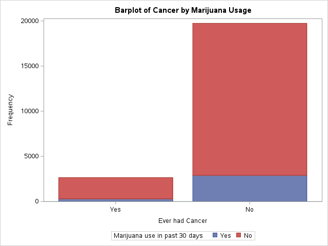

**log**

```
77                                                         The SAS System                      Friday, December 19, 2025 03:08:00 AM

692        ods listing close;ods html5 (id=saspy_internal) file=_tomods1 options(bitmap_mode='inline') device=svg style=HTMLBlue;
692      ! ods graphics on / outputfmt=png;
693
694        TITLE "Barplot of Cancer by Marijuana Usage";
695        PROC SGPLOT DATA = IMPT.BRFSS_FINAL;
696         VBAR Cancer / GROUP = Marijuana
697                     GROUPDISPLAY=STACK;
698         RUN;
699        TITLE;
700
701
702
703        ods html5 (id=saspy_internal) close;ods listing;
704
78                                                         The SAS System                      Friday, December 19, 2025 03:08:00 AM

705
```

# Results

# Create ODS Report

#### Set File Location and Start PDF

```sas
ODS PDF FILE = "&CourseRoot/BRFSS/Data/5_Results/SeanVieau Project 5 Report &SYSDATE.PDF" style = journal;
ODS LAYOUT START;
```

#### Create Header

```sas
TITLE FONT = ARIAL JUSTIFY = LEFT "Project 5. BRFSS Study";
TITLE2 FONT = ARIAL JUSTIFY = LEFT "Investigator: Sean Vieau";
TITLE3 FONT = ARIAL JUSTIFY = LEFT "Analyst: Sean Vieau";
TITLE4 FONT = ARIAL JUSTIFY = LEFT "&SysDate";
```

#### Print Table 1A

```sas
* Print Final clean table 1a;
TITLE5 FONT = ARIAL JUSTIFY = LEFT "Table 1A. Means and Standard Deviation";
PROC PRINT DATA = Table1_Clean LABEL NOOBS;
    RUN;
TITLE5;
```

#### Print Table 1B

```sas
* Print Final Clean Table 1b;
TITLE FONT = ARIAL JUSTIFY = LEFT "Table 1B. Frequency and Proportion";
PROC PRINT DATA = Table1b_Combine LABEL NOOBS;
    RUN;
TITLE;
```

#### Print Table 2

```sas
* Print Final Clean table 2;
TITLE FONT = ARIAL JUSTIFY = LEFT "Table 2. T-Test of BMI By State";
PROC PRINT DATA = Final_table2 NOOBS LABEL;
    RUN;
TITLE;
```

#### Print Table 3

```sas
* Print final table3;
TITLE FONT = ARIAL JUSTIFY = LEFT "Table 3. Multiple Logistic Regression Predicting Ever Having Cancer";
PROC PRINT DATA = Final_Table3 LABEL NOOBS;
    RUN;
TITLE;
```

#### Print Figure 1

```sas
* Print Final Figure 1;
TITLE1 FONT = ARIAL JUSTIFY = LEFT "Figure 1. Boxplot of BMI by State";
PROC SGPLOT DATA = IMPT.BRFSS_FINAL;
    WHERE State = "6" OR State = "8";
    VBOX BMI/CATEGORY=state NOOUTLIERS  fillattrs=(color=green) lineattrs=(color=black) whiskerattrs=(color=black) medianattrs=(color=black) meanattrs=(color=black);
    YAXIS MIN = 0 MAX = 60;
    RUN;
TITLE;
```

#### Print Figure 2

```sas
* Print Final Figure 2;
TITLE1 FONT = ARIAL JUSTIFY = LEFT "Figure 2. Barplot of Cancer by Marijuana Usage";
PROC SGPLOT DATA = IMPT.BRFSS_FINAL;
    VBAR Cancer / GROUP = Marijuana
                GROUPDISPLAY=STACK;
    RUN;
TITLE;
```

#### Close PDF

```sas
ODS LAYOUT END;
ODS PDF CLOSE;
```

# Final Report

[figure not shown]